# STAT 440: Homework Assignment #8

Due: Thursday, May 1 at 11:59pm on Canvas

Each of these exercises calls for writing code. Please use R, and turn in your code along with your written work and any plots you are asked to produce. Just as you strive for clarity in your writing of language, try to write R code that is easy to read, in the sense that a knowledgeable user of R would be able to understand it easily.

You *may* choose to use for your mathematics writing in your homework, in which case I recommend R Markdown as an easy way to combine text, mathematics, R code, and R output. But this is not required; you may choose to format your work however you find convenient, as long as you upload your assignment to Canvas as a single pdf document.

## Exercise 1

Consider the following covariance matrix:
$$\Sigma = \begin{pmatrix}
6 & -3 \\
-3 & 4
\end{pmatrix}$$

**Part (a)** Because $\Sigma$ is a symmetric, square matrix, its singular value decomposition (SVD) and its eigenvalue decomposition are the same as long as all its eigenvalues are nonnegative. In other words, we can write
$$\Sigma = VDV^\top,$$
where $D$ is a diagonal matrix with diagonal entries equal to the eigenvalues and $V$ is an orthogonal matrix (i.e., $V^\top V=I$).

Using the information that
$$v_1 = \begin{pmatrix} 1 + \sqrt{10} \\ -3 \end{pmatrix}
\quad \mbox{and} \quad
v_2 = \begin{pmatrix} 3 \\ 1+\sqrt{10} \end{pmatrix}$$
are eigenvectors of $\Sigma$, find the exact SVD of $\Sigma$ by hand.

**Hint:** If $v$ is an eigenvector of $\Sigma$, then the eigenvalue associated with $v$ is $\lambda$ such that $\Sigma v = \lambda v$.

**Part (b)** Write `R` code to verify that your answer from part (a) agrees with the output from `svd(Sigma)`, where `Sigma <- matrix(c(6, -3, -3, 4), 2, 2))`.

**Part (c)** Find the exact SVD of $\Sigma^{-1}$ by hand by inverting each of the factors in the SVD in part (a). Show all steps of your derivation.

**Part (d)** Write `R` code to verify that multiplying the SVD from part (c) to create $\sigma^{-1}$ agrees with `solve(Sigma)`.

### Answer

**Part (a)**

The covariance matrix is:
$$\Sigma =
\begin{bmatrix} 6 & -3 \\\\ -3 & 4 \end{bmatrix}$$
We are given two eigenvectors:
$$\mathbf{v}_1 =
\begin{bmatrix} 1 + \sqrt{10} \\\\ -3 \end{bmatrix}, \quad \mathbf{v}_2
= \begin{bmatrix} 3 \\\\ 1 + \sqrt{10} \end{bmatrix}$$
Their norm is:
$$\|\mathbf{v}_1\| =
\|\mathbf{v}_2\| = \sqrt{(1+\sqrt{10})^2 + 9} = \sqrt{20 + 2\sqrt{10}}$$
Thus, the normalized eigenvectors (orthonormal columns of $V$) are:
$$\hat{\mathbf{v}}_1 = \frac{1}{\sqrt{20 +
2\sqrt{10}}} \begin{bmatrix} 1 + \sqrt{10} \\\\ -3 \end{bmatrix}, \quad
\hat{\mathbf{v}}_2 = \frac{1}{\sqrt{20 + 2\sqrt{10}}} \begin{bmatrix} 3
\\\\ 1 + \sqrt{10} \end{bmatrix}$$
So the orthogonal matrix $V$ is:
$$V = \frac{1}{\sqrt{20 + 2\sqrt{10}}} \begin{bmatrix} 1 + \sqrt{10} &
3 \\\\ -3 & 1 + \sqrt{10} \end{bmatrix}$$
Next, we compute the eigenvalues of $\Sigma$ by solving:
$$\det(\Sigma - \lambda I) =
\lambda^2 - 10\lambda + 15 = 0$$
Using the quadratic formula:
$$\lambda = \frac{10 \pm \sqrt{100 - 60}}{2}
= \frac{10 \pm \sqrt{40}}{2} = 5 \pm \sqrt{10}$$
So the diagonal matrix $D$ of eigenvalues is:
$$D = \begin{bmatrix} 5 + \sqrt{10} & 0 \\\\ 0
& 5 - \sqrt{10} \end{bmatrix}$$
Hence, the **exact SVD** of $\Sigma$ is:
$$\Sigma = V D V^\top$$

**Part (b)**

```r
# Define the matrix Sigma
Sigma <- matrix(c(6, -3, -3, 4), nrow = 2, byrow = TRUE)

# Compute the SVD
svd_res <- svd(Sigma)

# Extract U, D, and V
U <- svd_res$u
D <- diag(svd_res$d)
V <- svd_res$v

# Reconstruct Sigma using the SVD
Sigma_reconstructed <- U %*% D %*% t(V)

# Print results
print(Sigma)
```

```
##      [,1] [,2]
## [1,]    6   -3
## [2,]   -3    4
```

```r
print(Sigma_reconstructed)
```

```
##      [,1] [,2]
## [1,]    6   -3
## [2,]   -3    4
```

```r
# Check if they are approximately equal
print(all.equal(Sigma, Sigma_reconstructed))
```

```
## [1] TRUE
```

**Part (c)**

We previously found the SVD of the symmetric matrix:
$$\Sigma = V D V^\top$$
Where:
$$V = \frac{1}{\sqrt{20 + 2\sqrt{10}}}
\begin{bmatrix} 1 + \sqrt{10} & 3 \\\\ -3 & 1 + \sqrt{10}
\end{bmatrix}, \quad D = \begin{bmatrix} 5 + \sqrt{10} & 0 \\\\ 0
& 5 - \sqrt{10} \end{bmatrix}$$
Since $\Sigma$ is symmetric and positive definite, we can invert it using the SVD identity:
$$\Sigma^{-1} = (V D V^\top)^{-1} = V D^{-1}
V^\top$$

#### Step 1: Invert the diagonal matrix

$D$ We compute $D^{-1}$ by inverting each diagonal entry:
$$D^{-1} = \begin{bmatrix} \frac{1}{5 +
\sqrt{10}} & 0 \\\\ 0 & \frac{1}{5 - \sqrt{10}} \end{bmatrix}$$
Rationalize the denominators:
$$\frac{1}{5 + \sqrt{10}} = \frac{5 - \sqrt{10}}{(5 + \sqrt{10})(5 -
\sqrt{10})} = \frac{5 - \sqrt{10}}{15}, \quad \frac{1}{5 - \sqrt{10}} =
\frac{5 + \sqrt{10}}{15}$$
So:
$$D^{-1} = \begin{bmatrix} \frac{5 - \sqrt{10}}{15} & 0 \\\\ 0 &
\frac{5 + \sqrt{10}}{15} \end{bmatrix}$$

#### Step 2: Reuse the orthogonal matrix

$V$
$$V = \frac{1}{\sqrt{20 + 2\sqrt{10}}} \begin{bmatrix} 1 + \sqrt{10} &
3 \\\\ -3 & 1 + \sqrt{10} \end{bmatrix}$$

#### Final Result: SVD of $\Sigma^{-1}$

$$\Sigma^{-1} = V D^{-1} V^\top$$
Where: - $V$ is the same orthogonal matrix as before - $D^{-1}$ is the inverse of the eigenvalue matrix:
$$D^{-1} =
\begin{bmatrix} \frac{5 - \sqrt{10}}{15} & 0 \\\\ 0 & \frac{5 +
\sqrt{10}}{15} \end{bmatrix}$$
Thus, we have the full, exact singular value decomposition of $\Sigma^{-1}$

**Part (d)**

```r
# Original matrix
Sigma <- matrix(c(6, -3, -3, 4), nrow = 2, byrow = TRUE)

# Solve Sigma directly
Sigma_inv_exact <- solve(Sigma)

# Step 1: Construct the orthonormal V matrix (from part a)
v1 <- c(1 + sqrt(10), -3)
v2 <- c(3, 1 + sqrt(10))

# Normalize eigenvectors
norm_val <- sqrt(sum(v1^2))  # Both v1 and v2 have same norm
v1_normalized <- v1 / norm_val
v2_normalized <- v2 / norm_val

# Build orthonormal V matrix
V <- cbind(v1_normalized, v2_normalized)

# Step 2: Construct inverse D matrix (from part c)
lambda1 <- 5 + sqrt(10)
lambda2 <- 5 - sqrt(10)
D_inv <- diag(c(1 / lambda1, 1 / lambda2))

# Step 3: Reconstruct Sigma^{-1} from the SVD
Sigma_inv_svd <- V %*% D_inv %*% t(V)

# Compare
print(Sigma_inv_exact)
```

```
##           [,1] [,2]
## [1,] 0.2666667  0.2
## [2,] 0.2000000  0.4
```

```r
print(Sigma_inv_svd)
```

```
##           [,1] [,2]
## [1,] 0.2666667  0.2
## [2,] 0.2000000  0.4
```

```r
print(all.equal(Sigma_inv_exact, Sigma_inv_svd))
```

```
## [1] TRUE
```

## Exercise 2

Principal component analysis (PCA) is a valuable tool for data exploration and is often employed as part of exploratory data analysis (EDA). Let’s apply PCA to the `USArrests` dataset in `R` to gain insights into the relationships between crime rates and urbanization. This dataset contains the number of arrests per 100,000 residents in each U.S. state in 1973 for Murder, Assault, and Rape. Additionally, it includes the percentage of the population in each state living in urban areas, represented by the variable UrbanPop.

```r
#load data
data("USArrests")

#view first six rows of data
head(USArrests)
```

```
##            Murder Assault UrbanPop Rape
## Alabama      13.2     236       58 21.2
## Alaska       10.0     263       48 44.5
## Arizona       8.1     294       80 31.0
## Arkansas      8.8     190       50 19.5
## California    9.0     276       91 40.6
## Colorado      7.9     204       78 38.7
```

**Part (a)** In `R`, define `X` to be the `USArrests` dataset with its column means subtracted from each column. In other words, the columns of `X` should be centered to have sample mean zero while retaining the same covariance structure as the original `USArrests` dataset:

```r
X <- as.matrix(sweep(USArrests, 2, colMeans(USArrests)))
## Verify that the column means of X are all zero:
colMeans(X)
```

```
##        Murder       Assault      UrbanPop          Rape
## -2.842171e-16  9.094947e-15 -6.252776e-15  8.526513e-16
```

Define `S` to be the sample covariance matrix of the `USArrests` dataset (you may either use the `cov` function or calculate `t(X) %*% X / (n-1)` directly, where `n` equals the number of observations in the `X` dataset. Check that these are the same!). Then define `e <- eigen(S)`. Finally, define `sv <- svd(X)`. Check that the $V$ matrix of the singular value decomposition gives the eigenvectors of the covariance matrix (remember, eigenvectors are scaled to have length 1 but their overall sign could be either direction). Also check that the eigenvalues of the covariance matrix, when multiplied by $n-1$, are the same as the squares of the signular values of $X$.

**Part (b)** Using either `e` or `sv`, find the first principal component, i.e., the eigenvector corresponding to the largest eigenvalue. Round this principal component to two decimal places and explain, in rough terms, how to interpret this first principal component. Also tell what percent of the total variation is explained by this first PC.

**Hint:** For the second principal component, the eigenvector rounded to two places equals $(0.04, 0.06, -0.98, -0.20)$ and we may interpret this as roughly minus one times the third variable (UrbanPop) added to one fifth of the fourth variable (Rape). The loadings on the other two variables are pretty close to zero so ignoring them to give a simplified interpretation seems reasonable.

**Part (c)** Now look at the diagonal entries of $S$ using `diag(S)`. Why does this output, combined with your answer from part (b), suggest that it would be better to perform principal components using the correlation matrix rather than the covariance matrix for this dataset?

**Part (d)** Using the eigendecomposition of `cor(X)`, focus on the first two principal components. What percent of the variation is explained by these first two PCs? (Explain your calculation.)

Once again rounding your eigenvectors to two decimal places, can you describe some rough intuition from the principal components loadings?

**Part (e)** If you right-multiply the matrix of eigenvectors by the $n\times 4$ data matrix in which each column is standardized to have unit variance, you will obtain a 4-column matrix where each column is the set of PC scores of all $n$ observations for the corresponding PC. Plot these PC scores for the first two principal components on a scatterplot. Ideally, you should label each point by the US State it represents.

Identify any outlying points you see and, using your answer from part (c), explain what the extreme PC scores tell us about the corresponding state(s).

**Hint:** To obtain the $n\times 4$ data matrix in which each column is standardized to have unit variance, use this code:

```
StDevs <- apply(USArrests, 2, sd)
sweep(USArrests, 2, StDevs, FUN = '/')
```

**Part (f)** Use `biplot(prcomp(USArrests, scale.=TRUE))` to produce a biplot of the first two principal component scores for every state along with a representation of the loadings on each variable for these two PCs. Compare this plot with the output from part (d); do you notice any differences?

### Answer

**Part (a)**

```r
S <- cov(X)
S_sample <- t(X) %*% X / (nrow(X) - 1)

#Check that the cov function is the same as the sample covariance
print(all.equal(S, S_sample))
```

```
## [1] TRUE
```

```r
e <- eigen(S)
sv <- svd(X)

for (i in 1:ncol(X)) {
  cat(paste("Component", i, ": "))
  match_sign <- all.equal(abs(e$vectors[, i]), abs(sv$v[, i]))
  print(match_sign)
}
```

```
## Component 1 : [1] TRUE
## Component 2 : [1] TRUE
## Component 3 : [1] TRUE
## Component 4 : [1] TRUE
```

```r
# Check that eigenvalues * (n - 1) == squared singular values
eig_scaled <- e$values * (nrow(X) - 1)
sv_squared <- sv$d^2

comparison <- data.frame(
  Eigen_times_n_minus_1 = eig_scaled,
  Singular_vals_squared = sv_squared,
  Difference = eig_scaled - sv_squared
)
print(comparison)
```

```
##   Eigen_times_n_minus_1 Singular_vals_squared    Difference
## 1           343544.6277           343544.6277  1.164153e-10
## 2             9897.6259             9897.6259  1.818989e-12
## 3             2063.5199             2063.5199  4.547474e-13
## 4              302.0481              302.0481 -1.136868e-13
```

**Part (b)**

```r
pc1 <- e$vectors[, 1]

# Round to two decimal places
pc1_rounded <- round(pc1, 2)
names(pc1_rounded) <- colnames(USArrests)

# Print first principal component
print("First principal component (rounded):")
```

```
## [1] "First principal component (rounded):"
```

```r
print(pc1_rounded)
```

```
##   Murder  Assault UrbanPop     Rape
##    -0.04    -1.00    -0.05    -0.08
```

```r
# Total variance = sum of all eigenvalues
total_variance <- sum(e$values)

# Proportion of variance explained by PC1
prop_variance_pc1 <- e$values[1] / total_variance
sprintf("PC1 explains %.2f%% of the total variance.", 100 * prop_variance_pc1)
```

```
## [1] "PC1 explains 96.55% of the total variance."
```

The loadings of this variable are about -1 on the 2nd variable, Assault; and not a very large component for the rest of them. This could mean that most of the data in this dataset is comprised of assaults.

**Part (c)**

```r
diag(S)
```

```
##     Murder    Assault   UrbanPop       Rape
##   18.97047 6945.16571  209.51878   87.72916
```

These values are the variances of each variable. Since the Assault variable has the highest variance, it means that Assault comprises a very high amount of variance in the entire dataset. This leads to our Principle Components having the most weight on the 2nd variable. Using correlation will be better, because it will lead to equal weight on all of the variables.

**Part (d)**

The First two principle components will be the first two eigenvectors of the covariance matrix.

```r
pc2 <- e$vectors[, 2]

pc2_rounded <- round(pc2, 2)
names(pc2_rounded) <- colnames(USArrests)

# Print first principal component
print("First and Second principal components (rounded):")
```

```
## [1] "First and Second principal components (rounded):"
```

```r
print(pc1_rounded)
```

```
##   Murder  Assault UrbanPop     Rape
##    -0.04    -1.00    -0.05    -0.08
```

```r
print(pc2_rounded)
```

```
##   Murder  Assault UrbanPop     Rape
##     0.04     0.06    -0.98    -0.20
```

To see the percent of variation that the first two PCs explain, we need to look at the eigenvalues.

```r
(e$values[1] + e$values[2]) / sum(e$values)
```

```
## [1] 0.9933516
```

Here we can see that the first 2 PCs make up 99.33% of the variance in the dataset.

The loadings for the second eigenvector is about 0.98 on the UrbanPop variable, so this means that this variable is most important in this PC. Also the Rape variable has a weight of 0.2, and the other ones are a lot smaller.

**Part (e)**

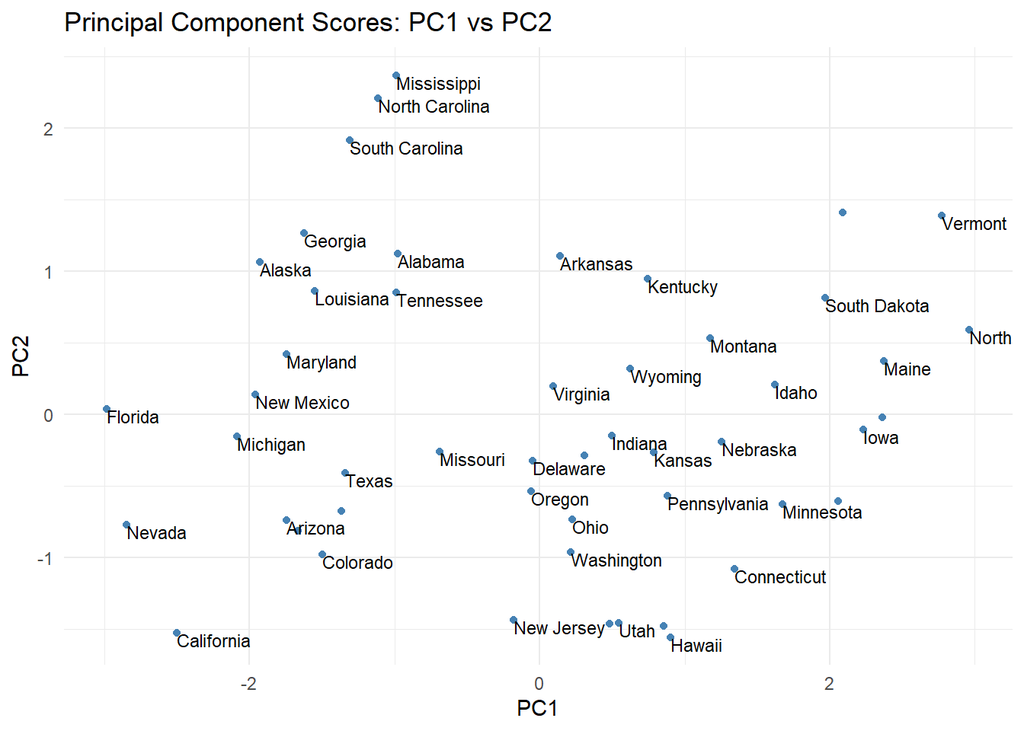

```r
StDevs <- apply(X, 2, sd)
X_std <- sweep(X, 2, StDevs, FUN = "/")

# Correlation matrix (since we standardized)
R <- cor(USArrests)

# Eigen decomposition of the correlation matrix
e_corr <- eigen(R)

# Get the matrix of eigenvectors (loadings)
V_corr <- e_corr$vectors  # 4x4

# Compute the PC scores (n x 4): right-multiply standardized data by eigenvectors
PC_scores <- as.matrix(X_std) %*% V_corr  # 50 x 4

# Create a dataframe for plotting
PC_df <- data.frame(
  State = rownames(USArrests),
  PC1 = PC_scores[, 1],
  PC2 = PC_scores[, 2]
)

# Plot PC1 vs PC2 with state labels
library(ggplot2)
ggplot(PC_df, aes(x = PC1, y = PC2, label = State)) +
  geom_point(color = "steelblue") +
  geom_text(hjust = 0, vjust = 1, size = 3, check_overlap = TRUE) +
  labs(title = "Principal Component Scores: PC1 vs PC2",
       x = "PC1",
       y = "PC2") +
  theme_minimal()
```

**Part (f)**

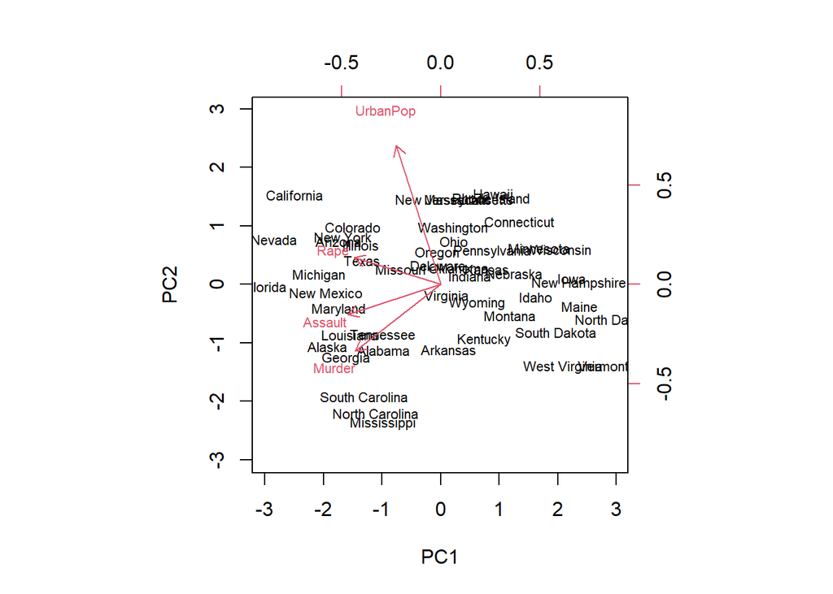

```r
# Compute PCA using correlation matrix (i.e., standardized data)
pca_result <- prcomp(USArrests, scale. = TRUE)

# Produce the biplot
biplot(pca_result, scale = 0, cex = 0.7)
```

## Exercise 3

This exercise reconsiders the example from the Week 15a notes. We have seen that the QR decomposition can be used to compute $\boldsymbol{\hat{\beta}}$, the least squares estimator of $\boldsymbol\beta$, in a linear regression problem. QR decomposition can also be used to compute the standard error (SE) estimate of $\boldsymbol{\hat{\beta}}$.

```r
n <- 50;M <- 500

x <- seq(1,M,len=n)
X <- cbind(1,x,x^2,x^3)
colnames(X) <- c("Intercept","x","x2","x3")

beta <- matrix(c(1,1,1,1),4,1)

set.seed(440)
y <- X%*%beta+rnorm(n,sd=1)

QR <- qr(X)
Q <- qr.Q( QR )
R <- qr.R( QR )
betahat <- backsolve(R, crossprod(Q,y) )
```

**Part (a)** Based on the QR decomposition, verify numerically that $\mathbf{X}^\top \mathbf{X}=\mathbf{R}^\top \mathbf{R}$. Use this result and the `chol2inv` function to compute $(\mathbf{X}^\top \mathbf{X})^{-1}$.

**Part (b)** The estimated SE of $\boldsymbol{\hat{\beta}}_i$ is given by

$$\sqrt{(n-p)^{-1}(\mathbf{Y}-\mathbf{X}\boldsymbol{\hat{\beta}})^\top
(\mathbf{Y}-\mathbf{X}\boldsymbol{\hat{\beta}})\cdot [(\mathbf{X}^\top
\mathbf{X})^{-1}]_{ii}},$$
where for $i=1,2,\ldots, p$, $\boldsymbol{\hat{\beta}}_i$ is the $i$-th element of the vector $\boldsymbol{\hat{\beta}}$, $[(\mathbf{X}^\top \mathbf{X})^{-1}]_{ii}$ is the $(i,i)$-th entry of the matrix $(\mathbf{X}^\top \mathbf{X})^{-1}$, $n$ is the sample size, and $p$ is the number of regression coefficients. For this dataset, $n=50$ and $p=4$. Based on your answers in the previous parts, write `R` code to estimate the SEs of $\boldsymbol{\hat{\beta}}$ based on the QR decomposition.

**Part (c)** Use the `lm` function to compute the estimated SEs of $\boldsymbol{\hat{\beta}}$ and compare the results based on `lm` with your answers from above.

### Answer

**Part (a)**

```r
XtX <- t(X) %*% X
RtR <- t(R) %*% R

#Are X'X and R'R equal?
print(all.equal(XtX, RtR))
```

```
## [1] TRUE
```

```r
# Compute (X'X)^(-1) using chol2inv
XtX_inv <- chol2inv(R)  # Because R is upper-triangular Cholesky factor of XtX

# Print inverse matrix
#Inverse of X'X using chol2inv(R)
print(XtX_inv)
```

```
##               [,1]          [,2]          [,3]          [,4]
## [1,]  2.847786e-01 -4.228115e-03  1.674440e-05 -1.934265e-08
## [2,] -4.228115e-03  8.651612e-05 -3.896682e-07  4.827453e-10
## [3,]  1.674440e-05 -3.896682e-07  1.878544e-09 -2.428319e-12
## [4,] -1.934265e-08  4.827453e-10 -2.428319e-12  3.231295e-15
```

**Part (b)**

```r
# Residuals and RSS
residuals <- y - X %*% betahat
rss <- sum(residuals^2)

# Degrees of freedom
p <- ncol(X)
sigma2_hat <- rss / (n - p)

# Standard errors from diagonal of (X'X)^-1
se_betahat <- sqrt(sigma2_hat * diag(XtX_inv))
names(se_betahat) <- colnames(X)

cat("Standard errors from QR decomposition:\n")
```

```
## Standard errors from QR decomposition:
```

```r
print(round(se_betahat, 6))
```

```
## Intercept         x        x2        x3
##  0.584491  0.010188  0.000047  0.000000
```

**Part (c)**

```r
# Fit model using lm
df <- data.frame(y = y, x = x, x2 = x^2, x3 = x^3)
lm_fit <- lm(y ~ x + x2 + x3, data = df)
se_lm <- summary(lm_fit)$coefficients[, "Std. Error"]

# Compare with QR-based SEs
comparison_df <- data.frame(
  SE_QR = round(se_betahat, 6),
  SE_lm = round(se_lm, 6),
  Difference = round(se_betahat - se_lm, 6)
)
print(comparison_df)
```

```
##              SE_QR    SE_lm Difference
## Intercept 0.584491 0.584491          0
## x         0.010188 0.010188          0
## x2        0.000047 0.000047          0
## x3        0.000000 0.000000          0
```